# hw05-donghan2

Donghan Liu, Donghan2

March 2, 2018

```r
# general
library(MASS)
library(caret)
library(tidyverse)
library(knitr)
library(kableExtra)

# specific
library(e1071)
library(nnet)
library(ellipse)
```

# Solution

## Exercise 1 (Detecting Cancer with KNN)

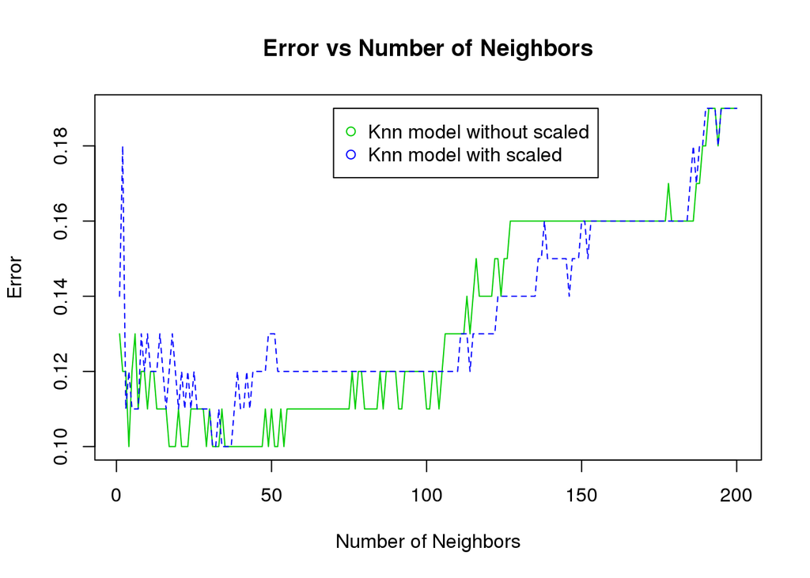

```r
wisc_trn = read.csv('wisc-trn.csv')
wisc_tst = read.csv('wisc-tst.csv')
calc_err = function(mod, data) {
  actual = data$class
  predicted = predict(mod, data, type = 'class')
  mean(actual != predicted)
}
knn_err = c()
knn_scaled_err = c()
for (i in 1:200){
  knn = knn3(factor(class) ~ radius + symmetry + texture, data = wisc_trn, k = i)
  knn_scaled = knn3(factor(class) ~ scale(radius) + scale(symmetry) + scale(texture), data = wisc_trn, k = i)
  knn_err[i] = calc_err(knn, wisc_tst)
  knn_scaled_err[i] = calc_err(knn_scaled, wisc_tst)
}
err = list(knn_err, knn_scaled_err)
dat = matrix(unlist(err), ncol = 2,byrow = FALSE)
matplot(dat,type = c("l"), pch = 1, col = 3:4, main = 'Error vs Number of Neighbors', xlab = 'Number of Neighbors', ylab = 'Error')
legend(70, 0.19, legend = c('Knn model without scaled','Knn model with scaled'), col=3:4, pch=1)
```

## Exercise 2 (Bias-Variance Tradeoff, Logistic Regression)

```r
set.seed(671434599)
make_sim_data = function(n_obs = 100) {
  x1 = runif(n = n_obs, min = 0, max = 2)
  x2 = runif(n = n_obs, min = 0, max = 4)
  prob = exp(1 + 2 * x1 - 1 * x2) / (1 + exp(1 + 2 * x1 - 1 * x2))
  y = rbinom(n = n_obs, size = 1, prob = prob)
  data.frame(y, x1, x2)
}
sim_data = make_sim_data()
```

```r
set.seed(671434599)
n_sims = 2000
n_models = 4
predictions = matrix(0, nrow = n_sims, ncol = n_models)
x =  data.frame(x1 = .50, x2 = .75)
for (sim in 1:n_sims){
  sim_data = make_sim_data(n_obs = 30)
  mod_1 = glm(y ~ 1, data = sim_data, family = "binomial")
  mod_2 = glm(y ~ x1 + x2, data = sim_data, family = "binomial")
  mod_3 = glm(y ~ x1 + x2 + x1 * x2, data = sim_data, family = "binomial")
  mod_4 = glm(y ~ x1 + x2 + I(x1^2) + I(x2^2) + x1 * x2, data = sim_data, family = "binomial")

  predictions[sim, 1] = predict(mod_1,x, type = "response")
  predictions[sim, 2] = predict(mod_2,x, type = "response")
  predictions[sim, 3] = predict(mod_3,x, type = "response")
  predictions[sim, 4] = predict(mod_4,x, type = "response")
}

get_mse = function(truth, estimate) {
  mean((estimate - truth) ^ 2)
}
get_bias = function(estimate, truth) {
  (mean(estimate) - truth) ^ 2
}
get_var = function(estimate) {
  mean((estimate - mean(estimate)) ^ 2)
}
f = function(x1, x2){
  exp(1 + 2 * x1 - 1 * x2) / (1 + exp(1 + 2 * x1 - 1 * x2))
}
bias = apply(predictions, 2, get_bias, truth = f(0.5,0.75))
variance = apply(predictions, 2, get_var)
mse = apply(predictions, 2, get_mse, truth = f(0.5,0.75))
results = data.frame(Model = c('Mod 1: y ~ 1', 'Mod 2: y ~ x1 + x2','Mod 3: y ~ x1 + x2 + x1 * x2', 'Mod 4: y ~ x1 + x2 + I(x1^2) + I(x2^2) + x1 * x2'), Bias = bias, Variance = variance, MSE = mse)
kable_styling(kable(results, format = "html", digits = 7), full_width = FALSE)
```

| Model | Bias | Variance | MSE |
| --- | --- | --- | --- |
| Mod 1: y ~ 1 | 0.0140264 | 0.0072814 | 0.0213078 |
| Mod 2: y ~ x1 + x2 | 0.0000017 | 0.0233385 | 0.0233403 |
| Mod 3: y ~ x1 + x2 + x1 * x2 | 0.0000752 | 0.0324136 | 0.0324888 |
| Mod 4: y ~ x1 + x2 + I(x1^2) + I(x2^2) + x1 * x2 | 0.0002326 | 0.0509943 | 0.0512270 |

## Exercise 3 (Comparing Classifiers)

```r
hw05_trn = read.csv("hw05-trn.csv")
hw05_tst = read.csv("hw05-tst.csv")
hw05_trn$y = factor(hw05_trn$y)
hw05_tst$y = factor(hw05_tst$y)
```

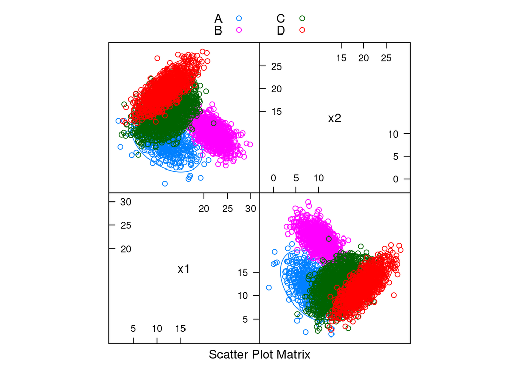

```r
featurePlot(x = hw05_trn[, c('x1','x2')],
                   y = hw05_trn$y,
                   plot = "ellipse",
                   auto.key = list(columns = 2))
```

```r
mod_addi = multinom(y ~ ., data = hw05_trn, trace = FALSE)
mod_lda = lda(y ~ ., data = hw05_trn)
mod_lda_flat = lda(y ~ ., data = hw05_trn, prior = c(1,1,1,1)/4)
mod_qda = qda(y ~ ., data = hw05_trn)
mod_qda_flat = qda(y ~ ., data = hw05_trn, prior = c(1,1,1,1)/4)
mod_nb = naiveBayes(y ~ ., data = hw05_trn)
```

```r
calc_class_err = function(actual, predicted) {
  mean(actual != predicted)
}

addi_trn = predict(mod_addi, hw05_trn)
lda_trn = predict(mod_lda, hw05_trn)$class
lda_flat_trn = predict(mod_lda_flat, hw05_trn)$class
qda_trn = predict(mod_qda, hw05_trn)$class
qda_flat_trn = predict(mod_qda_flat, hw05_trn)$class
nb_trn = predict(mod_nb, hw05_trn)

addi_tst = predict(mod_addi, hw05_tst)
lda_tst = predict(mod_lda, hw05_tst)$class
lda_flat_tst = predict(mod_lda_flat, hw05_tst)$class
qda_tst = predict(mod_qda, hw05_tst)$class
qda_flat_tst = predict(mod_qda_flat, hw05_tst)$class
nb_tst = predict(mod_nb, hw05_tst)

predict_trn = list(addi_trn, lda_trn, lda_flat_trn, qda_trn, qda_flat_trn, nb_trn)
predict_tst = list(addi_tst, lda_tst, lda_flat_tst, qda_tst, qda_flat_tst, nb_tst)

#Train error
trn_err = c()
for (i in predict_trn){
  trn_err = c(trn_err,calc_class_err(hw05_trn$y, i))
}
#Test error
tst_err = c()
for (i in predict_tst){
  tst_err = c(tst_err,calc_class_err(hw05_tst$y, i))
}

result = data.frame(Model = c('Additive','LDA','LDA flat','QDA','QDA flat','Naive Bayes'),Train_Error = trn_err, Test_Error = tst_err)
kable_styling(kable(result, format = "html", digits = 4), full_width = FALSE)
```

| Model | Train_Error | Test_Error |
| --- | --- | --- |
| Additive | 0.1482 | 0.1742 |
| LDA | 0.1620 | 0.1982 |
| LDA flat | 0.1904 | 0.1688 |
| QDA | 0.1478 | 0.1693 |
| QDA flat | 0.1791 | 0.1400 |
| Naive Bayes | 0.1733 | 0.2000 |

## Exercise 4 (Concept Checks)

**a**

The Mod 2: y ~ x1 + x2 has the lowest bias value, which is 0.0000017, it perhaps performs the best.

**b**

Even though model 1 has the lowest MSE value, the bias value of model 1 is much higher than the other three. The model 2 of y ~ x1 + x2 has the second lowest MSE and variance, the lowest bias value, so it might be the best model that perform well.

**c**

The model of QDA flat performs best because of the lowest test error

**d**

Because x1 and x2 violate the assumption of independence for Naive Bayes

**e**

QDA. First, QDA has the lower train and test error than LDA model. Second, due to that the data has different shape and mean and location, the QDA potentially performs better

**f**

Flat prior performs better because of lower test error than non-flat prior model.

**g**

From the intutional view, class B is the easiest to classify. First, the overlap area between class B and other classes is relatively smaller. Plus, all of other three classes located in the pretty close position and the shape also different from C and D.